# Final Tutorial: Financial Analysis Project

### Group Members: Ritika Mishra and Raymond Liu

## Project Link: https://ritikamishra11.github.io/financial_analysis_project_milestone3.html

## Tutorial Overview:

In this tutorial, we will make a preliminary exploration on the US stock market through techniques in data science. The financial markets are complex, with stock prices influenced by multiple factors. In this tutorial, in order to simplify and make it suitable for beginners in financial analysis, we will concentration on two representative stocks. Specifically, we will focus on analyzing Apple Inc.'s and Microsoft's stock prices using various statistical and analytical techniques, such as data exploration, correlation analysis, and MACD (Moving Average Convergence Divergence) calculations. We will also apply linear regression models to examine the relationship between stock prices and time for Apple Inc.

### Research Questions:

- What is the historical volatility of Apple and Microsoft stock prices?
- How do Apple Inc.'s and Microsoft's stock prices compare in terms of historical trends and correlations?
- How can linear regression models help understand the relationship between stock prices and time?

## Data Source:

The source data consists of fundamental stock information for Apple and Microsoft from 1988-09-01 to 2024-10-11. The data contains adjusted price, volume, open, low, and high prices, which are all basic components of a stock. We downloaded the data from a public website, "Investors FastTrack," which has open-sourced stock information

Data Link: https://ftcloud.fasttrack.net/web/xreport/stocks?token=41985F2A-D605-4AD9-B0B9-046390223BEC

## Extraction, Transform, and Load (ETL):

**Overview**

For our ETL process, we began by uploading daily stock price data for Apple Inc. and Microsoft Corporation. The data was loaded into pandas DataFrames and included fields. We transformed the data by converting the Date column to a datetime format for easier date manipulation. Additionally, we ensured that data types for numerical columns were correctly set to float or integer as appropriate. To maintain tidy data principles, each variable was kept in its own column, each observation in its own row, and each type of observational unit formed its own table. To ensure comparability, both datasets were aligned to have the same date range. Finally, we verified data consistency and displayed key samples for an initial overview, laying the groundwork for further analysis.

**Load and Check all data:**

The following code is about loading and checking stock data for Apple and Microsoft. We firstly imported essential libraries and uploaded necessary datasets through pandas' read_csv() function. To ensure the data is correctly loaded, we printed the column names, data types, and a few sample rows for both datasets to confirm the structure and content.

```python
import pandas as pd
import numpy as np
import matplotlib.pyplot as plt
from google.colab import files

# Upload CSV files for both datasets
uploaded = files.upload()

# Ensure plots display inline in the notebook
%matplotlib inline

# Load the Apple and Microsoft data
apple_data = pd.read_csv('AAPL.csv')
apple_data['Date'] = pd.to_datetime(apple_data['Date'])
msft_data = pd.read_csv('MSFT.csv')
msft_data['Date'] = pd.to_datetime(msft_data['Date'])

# Check the structure of the data to ensure the correct columns are present
print("Apple Data Columns:")
print(apple_data.columns)
print("\nApple Data Types:")
print(apple_data.dtypes)
print("\nFirst 5 rows of Apple Data:")
print(apple_data.head())

print("\nMicrosoft Data Columns:")
print(msft_data.columns)
print("\nMicrosoft Data Types:")
print(msft_data.dtypes)
print("\nFirst 5 rows of Microsoft Data:")
print(msft_data.head())
```

Upload widget is only available when the cell has been executed in the current browser session. Please rerun this cell to enable.

```
Saving MSFT.csv to MSFT (1).csv
Saving AAPL.csv to AAPL (1).csv
Apple Data Columns:
Index(['Date', 'Adjusted Price', 'Open', 'Low', 'High', 'Volume'], dtype='object')

Apple Data Types:
Date              datetime64[ns]
Adjusted Price           float64
Open                     float64
Low                      float64
High                     float64
Volume                   float64
dtype: object

First 5 rows of Apple Data:
        Date  Adjusted Price   Open    Low   High    Volume
0 1988-09-01           0.270  0.270  0.267  0.277  246736.0
1 1988-09-02           0.277  0.277  0.270  0.279  186300.8
2 1988-09-06           0.270  0.270  0.269  0.279  143449.6
3 1988-09-07           0.266  0.266  0.262  0.276  179110.4
4 1988-09-08           0.270  0.270  0.262  0.276  207256.0

Microsoft Data Columns:
Index(['Date', 'Adjusted Price', 'Open', 'Low', 'High', 'Volume'], dtype='object')

Microsoft Data Types:
Date              datetime64[ns]
Adjusted Price           float64
Open                     float64
Low                      float64
High                     float64
Volume                   float64
dtype: object

First 5 rows of Microsoft Data:
        Date  Adjusted Price   Open    Low   High     Volume
0 1988-09-01           0.211  0.211  0.207  0.216   82382.39
1 1988-09-02           0.223  0.223  0.213  0.225  115329.60
2 1988-09-06           0.225  0.225  0.221  0.228   67751.99
3 1988-09-07           0.224  0.224  0.219  0.229   72115.20
4 1988-09-08           0.225  0.225  0.221  0.231   69206.40
```

**Aligning and Validating Stock Data:**

In our tutorial, this step can be igorned because we have already had data following a tidy principle. However, in order to further extand and generalize our totorial, we still wrote a few lines of code to align datasets to the same date range by finding the overlapping period. This can guarantee our data always aligns with tidy data principles.

```python
# Align both datasets to the same date range
start_date = max(apple_data['Date'].min(), msft_data['Date'].min())
end_date = min(apple_data['Date'].max(), msft_data['Date'].max())
apple_data = apple_data[(apple_data['Date'] >= start_date) & (apple_data['Date'] <= end_date)]
msft_data = msft_data[(msft_data['Date'] >= start_date) & (msft_data['Date'] <= end_date)]

# Check data consistency
if len(apple_data) != len(msft_data):
    print("\nWarning: The datasets have different lengths after date alignment.")
else:
    print("\nThe datasets are aligned with the same number of records.")

# Display the adjusted date ranges
print("\nDate range for aligned datasets:")
print(f"Start Date: {start_date}")
print(f"End Date: {end_date}")

# Display a quick overview of aligned data
print("\nAligned Apple Data Sample:")
print(apple_data.head())
print("\nAligned Microsoft Data Sample:")
print(msft_data.head())
```

```
The datasets are aligned with the same number of records.

Date range for aligned datasets:
Start Date: 1988-09-01 00:00:00
End Date: 2024-10-11 00:00:00

Aligned Apple Data Sample:
        Date  Adjusted Price   Open    Low   High    Volume
0 1988-09-01           0.270  0.270  0.267  0.277  246736.0
1 1988-09-02           0.277  0.277  0.270  0.279  186300.8
2 1988-09-06           0.270  0.270  0.269  0.279  143449.6
3 1988-09-07           0.266  0.266  0.262  0.276  179110.4
4 1988-09-08           0.270  0.270  0.262  0.276  207256.0

Aligned Microsoft Data Sample:
        Date  Adjusted Price   Open    Low   High     Volume
0 1988-09-01           0.211  0.211  0.207  0.216   82382.39
1 1988-09-02           0.223  0.223  0.213  0.225  115329.60
2 1988-09-06           0.225  0.225  0.221  0.228   67751.99
3 1988-09-07           0.224  0.224  0.219  0.229   72115.20
4 1988-09-08           0.225  0.225  0.221  0.231   69206.40
```

## Exploratory Data Analysis (EDA):

**Overview**

For our EDA portion, we firstly made calculations on basic financial statistics, such as mean, median, and so on. They were useful for further exploration and also made the first step of our EDA research. With fundamental measures, we were able to generate some graphs to visualize stock information. We plotted history stock price charts and Moving Average Convergence/Divergence (MACD) to further understand the stock movements. Additionally, we tried to reveal the correlation between Apple and Microsoft's stock prices by calculating the Pearson correlation coefficient because Apple and Microsoft are typical technology companies, which might have certain correlations in our assumptions. Finally, we applied linear regression models to try to reveal the trend in price flow for Apple stock.

## Summary Statistics Explained

Before starting any analysis, it is important to understand the characteristics of stock prices themselves. The following metrics provide key insights into stock performance and risk, which set up a solid background for further analysis.

- **Mean Price**: The average adjusted price
- **Median Price**: The median adjusted price, providing a robust measure of central tendency.
- **Price Standard Deviation**: A measure of price volatility over the period.
- **Minimum and Maximum Price**: The lowest and highest prices in the dataset, giving the range of price movement.
- **Annualized Return**: The average return of the stock over a year.
- **Annualized Volatility**: The volatility of the stock price over a year, important for assessing risk.
- **Skewness**: The asymmetry of daily returns, showing whether returns are more likely to be extreme gains or losses.
- **Kurtosis**: The tailedness of the return distribution, highlighting the likelihood of outliers.
- **Max Drawdown**: The largest peak-to-trough decline, showing the worst-case downside risk.

```python
# Function to calculate and display summary statistics
def summary_statistics(data, stock_name='Stock'):
    if 'Adjusted Price' not in data.columns:
        raise KeyError(f"'Adjusted Price' column is missing in the {stock_name} data.")

    # Ensure daily return column exists
    if 'Daily Return' not in data.columns:
        data['Daily Return'] = data['Adjusted Price'].pct_change()

    # Drop NaN values from 'Daily Return'
    data_cleaned = data.dropna(subset=['Daily Return'])

    # Calculate summary statistics
    summary_stats = {
        f"{stock_name} Mean Price": data['Adjusted Price'].mean(),
        f"{stock_name} Median Price": data['Adjusted Price'].median(),
        f"{stock_name} Price Standard Deviation": data['Adjusted Price'].std(),
        f"{stock_name} Minimum Price": data['Adjusted Price'].min(),
        f"{stock_name} Maximum Price": data['Adjusted Price'].max(),
        f"{stock_name} Annualized Return": data_cleaned['Daily Return'].mean() * 252,  # 252 trading days
        f"{stock_name} Annualized Volatility": data_cleaned['Daily Return'].std() * np.sqrt(252),
        f"{stock_name} Skewness": data_cleaned['Daily Return'].skew(),
        f"{stock_name} Kurtosis": data_cleaned['Daily Return'].kurtosis(),
        f"{stock_name} Max Drawdown": max_drawdown(data['Adjusted Price'])
    }

    return summary_stats

# Function to calculate the maximum drawdown (peak-to-trough decline)
def max_drawdown(prices):
    running_max = prices.cummax()  # Calculate the running maximum price
    drawdown = (prices - running_max) / running_max  # Calculate the percentage drawdown
    return drawdown.min()  # Return the largest drawdown

# Calculate and print summary statistics for Apple data
apple_stats = summary_statistics(apple_data, stock_name='Apple')
print("Apple Summary Statistics:")
for stat, value in apple_stats.items():
    print(f"{stat}: {value}")

# Calculate and print summary statistics for Microsoft data
msft_stats = summary_statistics(msft_data, stock_name='Microsoft')
print("\nMicrosoft Summary Statistics:")
for stat, value in msft_stats.items():
    print(f"{stat}: {value}")
```

```
Apple Summary Statistics:
Apple Mean Price: 27.23105583644757
Apple Median Price: 2.262
Apple Price Standard Deviation: 51.104290844199525
Apple Minimum Price: 0.098
Apple Maximum Price: 234.55
Apple Annualized Return: 0.2778283503745821
Apple Annualized Volatility: 0.42291299754761136
Apple Skewness: -0.3984390466453507
Apple Kurtosis: 23.9108741077217
Apple Max Drawdown: -0.8178472861085557

Microsoft Summary Statistics:
Microsoft Mean Price: 58.503084084414155
Microsoft Median Price: 20.232
Microsoft Price Standard Deviation: 95.6903149802217
Microsoft Minimum Price: 0.199
Microsoft Maximum Price: 466.729
Microsoft Annualized Return: 0.26039357591804385
Microsoft Annualized Volatility: 0.3168941099980314
Microsoft Skewness: 0.17220409040583787
Microsoft Kurtosis: 6.2719834436926885
Microsoft Max Drawdown: -0.6944362117742152
```

**Data Interpretation:**

These statistics provide valuable insights into Apple and Microsoft's stock behaviors by offering different perspectives on its performance. The mean and median prices help in understanding the typical price levels, giving investors a sense of where the stock usually trades. Volatility measures, such as the standard deviation and annualized volatility, are crucial for assessing the risk associated with holding the stock, as they indicate the extent of price fluctuations. Skewness and kurtosis offer deeper insights into the distribution of returns, highlighting the likelihood of extreme gains or losses. Finally, the max drawdown is particularly important for risk management, as it shows the worst-case scenario for an investor by quantifying the largest historical peak-to-trough decline in the stock's value. Together, these statistics form a comprehensive picture of the stock’s risk and return characteristics.

## Visualizing Stock Prices:

Now, Let's try to visualize some graphs for better understanding stock prices. In this part, we are going to plot adjusted stock prices over the years using matplotlib. It is significant because it allows us to compare the historical performance of Apple and Microsoft.

```
Visualizing Apple Adjusted Price over the years:
```

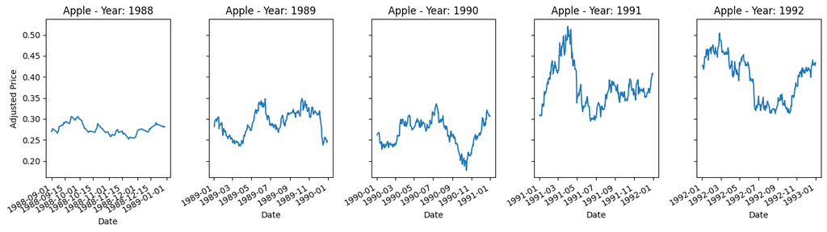

```
Visualizing Microsoft Adjusted Price over the years:
```

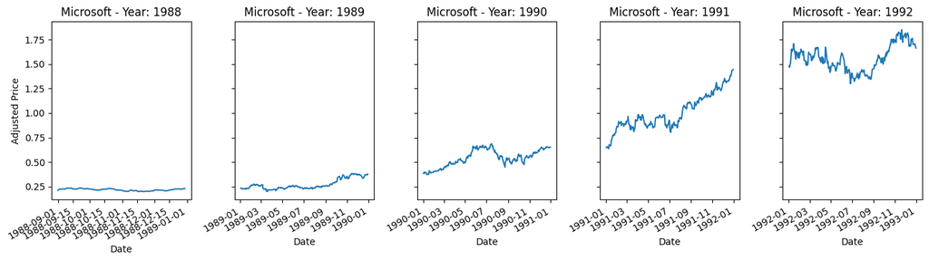

```python
# Function to visualize adjusted price over years
def plot_adjusted_price_by_year(data, stock_name='Stock'):
    # Convert 'Date' column to datetime if not already
    data['Date'] = pd.to_datetime(data['Date'])

    # Extract unique years from 'Date' column
    years = data['Date'].dt.year.unique()

    # Create a 1x5 grid for visualizing the adjusted price over 5 different years
    fig, axes = plt.subplots(1, len(years[:5]), figsize=(14, 4), sharey=True)  # Limiting to first 5 years

    # Loop over each unique year and plot the Adjusted Price for that year
    for ax, year in zip(axes, years[:5]):  # Limiting to first 5 years for better visualization
        yearly_data = data[data['Date'].dt.year == year]

        # Plot Adjusted Price over time for that year
        yearly_data.plot(x='Date', y='Adjusted Price', ax=ax, legend=False)

        # Set title and labels
        ax.set_title(f"{stock_name} - Year: {year}")
        ax.set_xlabel('Date')
        ax.set_ylabel('Adjusted Price')

    # Adjust layout to prevent overlap
    plt.tight_layout()
    plt.show()

# Plotting for Apple data
print("Visualizing Apple Adjusted Price over the years:")
plot_adjusted_price_by_year(apple_data, stock_name='Apple')

# Plotting for Microsoft data
print("\nVisualizing Microsoft Adjusted Price over the years:")
plot_adjusted_price_by_year(msft_data, stock_name='Microsoft')
```

# Technical Indicators for Stocks

After gaining a basic understanding of stock price movements, let's dive deeper into exploring Technical Indicators for Stocks, such as the Moving Average Convergence/Divergence (MACD), the Pearson correlation coefficient, and the correlation heatmap.

## Trading Indicator: Moving Average Convergence/Divergence (MACD)

*For More detailed information, access to this link:* https://www.investopedia.com/terms/m/macd.asp#:~:text=Key%20Takeaways,EMA%20of%20the%20MACD%20line.

```
Apple MACD (Last 365 Days):
```

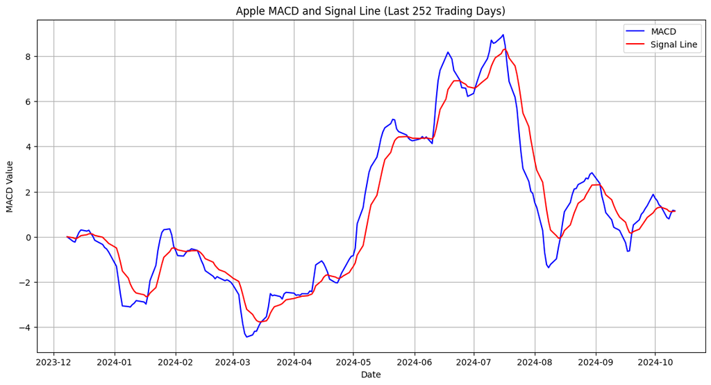

```
Original Apple Data Range: 1988-09-01 00:00:00 to 2024-10-11 00:00:00
Filtered MACD Data Range: 2023-12-08 00:00:00 to 2024-10-11 00:00:00

Microsoft MACD (Last 365 Days):
```

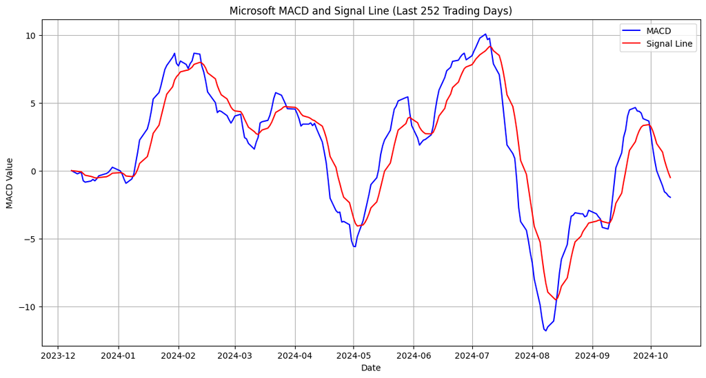

```
Original Microsoft Data Range: 1988-09-01 00:00:00 to 2024-10-11 00:00:00
Filtered MACD Data Range: 2023-12-08 00:00:00 to 2024-10-11 00:00:00
```

```python
from datetime import datetime, timedelta
import matplotlib.pyplot as plt

# Function to calculate MACD
def calculate_macd(data, stock_name='Stock'):
    # Create a copy of the data to avoid modifying the original dataset
    macd_data = data.copy()

    # Ensure the data is sorted by date
    macd_data = macd_data.sort_values(by='Date')

    # Filter data for the last 365 days and create a new copy
    one_year_ago = datetime.now() - timedelta(days=365)
    filtered_data = macd_data[macd_data['Date'] >= one_year_ago].copy()

    # Calculate short-term and long-term EMA
    short_ema = filtered_data['Adjusted Price'].ewm(span=12, adjust=False).mean()
    long_ema = filtered_data['Adjusted Price'].ewm(span=26, adjust=False).mean()

    # Calculate MACD and Signal Line
    macd = short_ema - long_ema
    signal_line = macd.ewm(span=9, adjust=False).mean()

    # Add MACD and Signal Line to the filtered DataFrame
    filtered_data.loc[:, 'MACD'] = macd
    filtered_data.loc[:, 'Signal Line'] = signal_line

    # Plotting
    plt.figure(figsize=(14, 7))
    plt.plot(filtered_data['Date'], filtered_data['MACD'], label='MACD', color='blue')
    plt.plot(filtered_data['Date'], filtered_data['Signal Line'], label='Signal Line', color='red')
    plt.title(f"{stock_name} MACD and Signal Line (Last 252 Trading Days)")
    plt.xlabel('Date')
    plt.ylabel('MACD Value')
    plt.legend()
    plt.grid(True)
    plt.show()

    return filtered_data  # Return only the MACD-calculated DataFrame

# Calculate MACD for Apple data
print("Apple MACD (Last 365 Days):")
apple_macd_data = calculate_macd(apple_data, stock_name='Apple')

# Original Apple data remains unchanged
print("\nOriginal Apple Data Range:", apple_data['Date'].min(), "to", apple_data['Date'].max())
print("Filtered MACD Data Range:", apple_macd_data['Date'].min(), "to", apple_macd_data['Date'].max())

# Calculate MACD for Microsoft data
print("\nMicrosoft MACD (Last 365 Days):")
msft_macd_data = calculate_macd(msft_data, stock_name='Microsoft')

# Original Microsoft data remains unchanged
print("\nOriginal Microsoft Data Range:", msft_data['Date'].min(), "to", msft_data['Date'].max())
print("Filtered MACD Data Range:", msft_macd_data['Date'].min(), "to", msft_macd_data['Date'].max())
```

**Graph Interpretation:**

These graphs are crucial for identifying potential buy and sell signals in stock trading. By observing the crossings and divergences between the MACD and Signal Line, we better understood momentum and price trends for apple and microsoft: a buy signal occurs when the MACD crosses above the Signal Line, and a sell signal occurs when it crosses below.

## Pearson correlation coefficient (Correlation between Apple and Microsoft）

In statistics, the Pearson correlation coefficient (PCC) is used to calculate a linear correlation between two sets of data. In our project, we applied it in calculating a correlation between Apple and Microsoft's stock prices, which were both considered representative technology companies. We firstly calculated daily returns from adjusted prices and combined both sets of returns into one dataframe. With python function of "corr()" and matplotlib, we were able to calculate them and plotted them with a scatter plot to visualize the relationship between the daily returns of Apple and Microsoft.

*For More detailed information, access to this link:* https://www.sciencedirect.com/topics/computer-science/pearson-correlation

```
Correlation between Apple and Microsoft Daily Returns: 0.4059
```

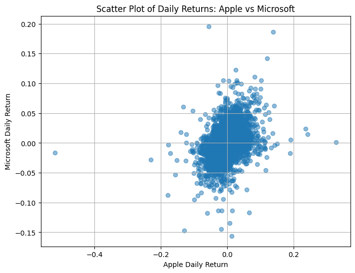

```python
# Ensure daily returns are calculated
if 'Daily Return' not in apple_data.columns:
    apple_data['Daily Return'] = apple_data['Adjusted Price'].pct_change()

if 'Daily Return' not in msft_data.columns:
    msft_data['Daily Return'] = msft_data['Adjusted Price'].pct_change()

# Combine daily returns data
combined_returns = pd.DataFrame({
    'Apple': apple_data['Daily Return'],
    'Microsoft': msft_data['Daily Return']
}).dropna()  # Remove missing values

# Calculate correlation
correlation = combined_returns.corr().loc['Apple', 'Microsoft']
print(f"Correlation between Apple and Microsoft Daily Returns: {correlation:.4f}")

# Plot correlation
plt.figure(figsize=(8, 6))
plt.scatter(combined_returns['Apple'], combined_returns['Microsoft'], alpha=0.5)
plt.title('Scatter Plot of Daily Returns: Apple vs Microsoft')
plt.xlabel('Apple Daily Return')
plt.ylabel('Microsoft Daily Return')
plt.grid(True)
plt.show()
```

**Graph Interpretation:**

This scatterplot illustrates the relationship between the daily returns of Apple and Microsoft stocks. This scatter plot was important to our understanding of the stocks because witnissing the correlation between the two, showing how movements in one stock's returns are often mirrored by the other, indicating potential interdependence in their market behavior. Seeing the dense positive correlation which may indicate that the stocks often move in the same direction helped us understand the importance of shared market trends.

## Visualizing Stock Prices and Trading Volumes

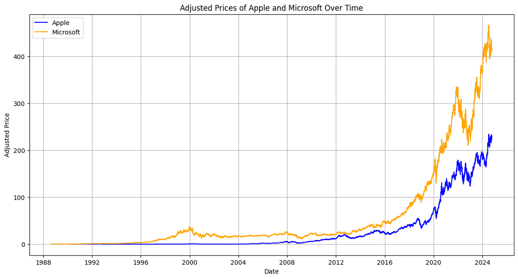

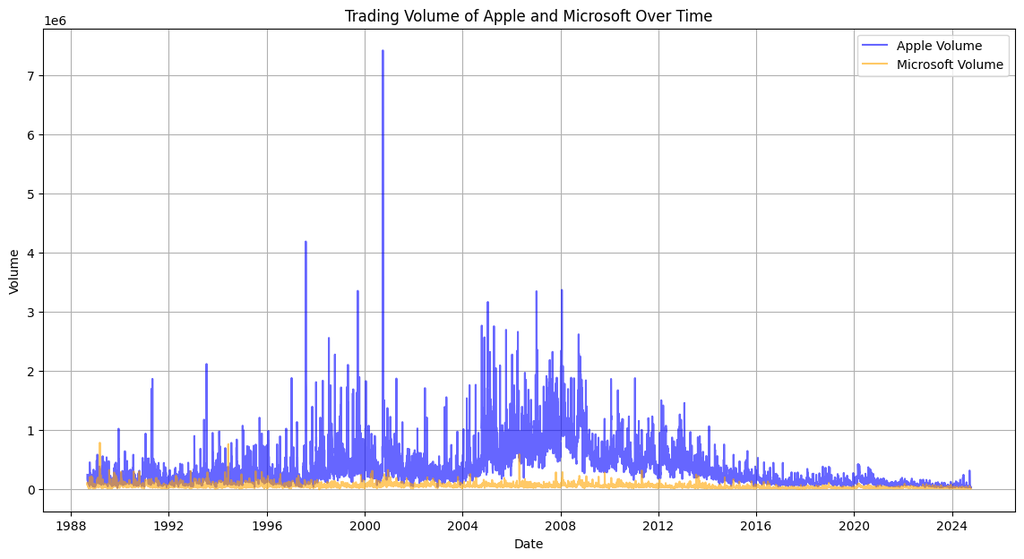

```python
apple_data['Date'] = pd.to_datetime(apple_data['Date'], format='%m/%d/%Y')
msft_data['Date'] = pd.to_datetime(msft_data['Date'], format='%m/%d/%Y')

# Time Series Plot of Adjusted Prices for Apple and Microsoft
plt.figure(figsize=(14, 7))
plt.plot(apple_data['Date'], apple_data['Adjusted Price'], label='Apple', color='blue')
plt.plot(msft_data['Date'], msft_data['Adjusted Price'], label='Microsoft', color='orange')
plt.title('Adjusted Prices of Apple and Microsoft Over Time')
plt.xlabel('Date')
plt.ylabel('Adjusted Price')
plt.legend()
plt.grid(True)
plt.show()

# Volume Analysis - Plotting Trading Volumes over time for Apple and Microsoft
plt.figure(figsize=(14, 7))
plt.plot(apple_data['Date'], apple_data['Volume'], label='Apple Volume', color='blue', alpha=0.6)
plt.plot(msft_data['Date'], msft_data['Volume'], label='Microsoft Volume', color='orange', alpha=0.6)
plt.title('Trading Volume of Apple and Microsoft Over Time')
plt.xlabel('Date')
plt.ylabel('Volume')
plt.legend()
plt.grid(True)
plt.show()
```

**Graph Interpretation:**

The second graph depicts the trading volumes of Apple and Microsoft stocks, illustrating periods of high and low trading activity. Volume trends can indicate investor sentiment and liquidity, factors that could impact price movements. From thsi graph, our interest in focusing on apple stocks for our regression model peaked. We notice significant spikes in trading activity, particularly during market events like the dot-com boom around 2000. We were able to see how product launches really influenced the significant spikes in Apple's trading volume.

## Correlation Heatmap

The correlation heatmap shows relationships between Apple and Microsoft prices, volumes, and daily returns. The strong correlations highlight interconnected movements between these stocks, suggesting that price or return changes in one stock might affect the other.

*For More detailed information, access to this link:* https://www.quanthub.com/how-to-read-a-correlation-heatmap/#:~:text=A%20correlation%20heatmap%20is%20a,closely%20related%20different%20variables%20are.

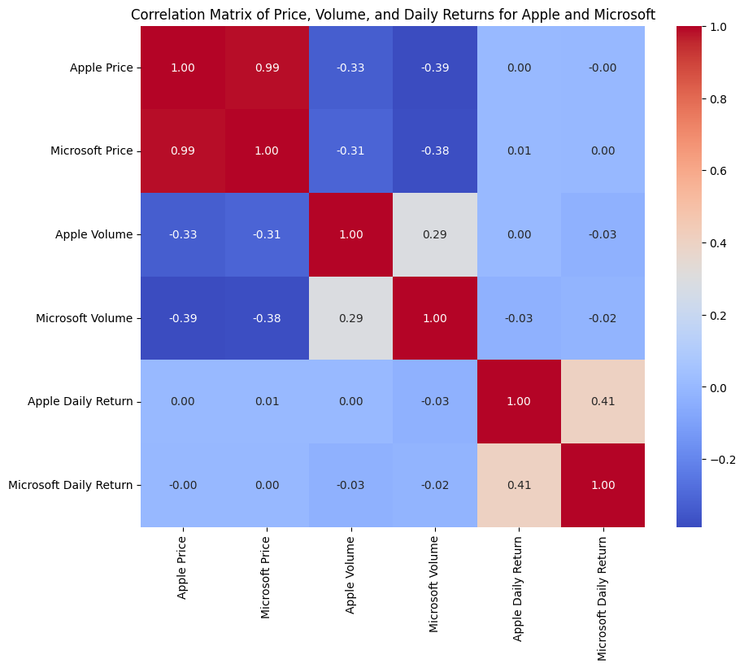

```python
#Need to makesure seaborn is installed, use the following command: !pip install seaborn
import seaborn as sns

combined_data = pd.merge(apple_data[['Date', 'Adjusted Price', 'Volume']].rename(
                            columns={'Adjusted Price': 'Apple Price', 'Volume': 'Apple Volume'}),
                         msft_data[['Date', 'Adjusted Price', 'Volume']].rename(
                            columns={'Adjusted Price': 'Microsoft Price', 'Volume': 'Microsoft Volume'}),
                         on='Date')


combined_data['Apple Daily Return'] = combined_data['Apple Price'].pct_change()
combined_data['Microsoft Daily Return'] = combined_data['Microsoft Price'].pct_change()


combined_data = combined_data.dropna()


correlation_matrix = combined_data[['Apple Price', 'Microsoft Price',
                                    'Apple Volume', 'Microsoft Volume',
                                    'Apple Daily Return', 'Microsoft Daily Return']].corr()


plt.figure(figsize=(10, 8))
sns.heatmap(correlation_matrix, annot=True, cmap="coolwarm", fmt=".2f")
plt.title('Correlation Matrix of Price, Volume, and Daily Returns for Apple and Microsoft')
plt.show()
```

**Graph Interpretation:** We created this heatmap to show correlations between different metrics, including price, volume, and daily returns for Apple and Microsoft. From this graph, we were able to see a strong correlation (0.99) between Apple and Microsoft prices, confirming their synchronized movements, as we earlier noticed as well in the other graphs. From this graph we were also able to see that some of the lower correlations, between volume and price, suggests that trading volume may not directly influence short-term price changes but is still a significant indicatior of market activity.

## Linear Regression Model

In this part, we focus on creating linear regression models to explore a potential relationship between Apple stock prices and time. The real-life situation might be more complicated and uninterpretable. However, we conducted this project in a highly simplified scenario for research purposes, which we only focus on linear relationship between prices and time. Our goal is to have an introductory exploration towards quantitative finance.

For below linear regression model, we applied all historical data from 1988 to 2024:

```
Model Coefficient (Slope): 0.00951259238568988
Model Intercept: -35.98482102886148
Training Mean Squared Error (MSE): 1240.60
Training R² Score: 0.51
Validation Mean Squared Error (MSE): 1335.90
Validation R² Score: 0.52
```

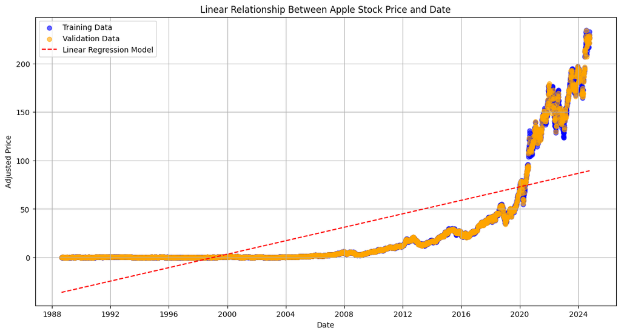

```python
from sklearn.model_selection import train_test_split
from sklearn.linear_model import LinearRegression
from sklearn.metrics import mean_squared_error, r2_score
import matplotlib.pyplot as plt

# Convert dates to numerical values
apple_data['Days'] = (apple_data['Date'] - apple_data['Date'].min()).dt.days

# Prepare the data with indices
X = apple_data['Days'].values.reshape(-1, 1)  # Independent variable: number of days
y = apple_data['Adjusted Price'].values     # Dependent variable: adjusted prices
indices = apple_data.index            # Save original indices

# Split the data into training and validation sets (70% training, 30% validation), keeping track of indices
X_train, X_val, y_train, y_val, train_idx, val_idx = train_test_split(
    X, y, indices, test_size=0.3, random_state=42
)

# Create and fit the linear regression model on the training set
model = LinearRegression()
model.fit(X_train, y_train)

# Generate predictions for the training and validation sets
y_train_pred = model.predict(X_train)
y_val_pred = model.predict(X_val)

# Print model coefficients
print(f"Model Coefficient (Slope): {model.coef_[0]}")
print(f"Model Intercept: {model.intercept_}")

# Evaluate the model on the training set
train_mse = mean_squared_error(y_train, y_train_pred)
train_r2 = r2_score(y_train, y_train_pred)
print(f"Training Mean Squared Error (MSE): {train_mse:.2f}")
print(f"Training R² Score: {train_r2:.2f}")

# Evaluate the model on the validation set
val_mse = mean_squared_error(y_val, y_val_pred)
val_r2 = r2_score(y_val, y_val_pred)
print(f"Validation Mean Squared Error (MSE): {val_mse:.2f}")
print(f"Validation R² Score: {val_r2:.2f}")

# Add a column for predicted prices
apple_data['Predicted Price'] = model.predict(X)

# Visualize the model performance with actual dates on the x-axis
plt.figure(figsize=(14, 7))
plt.scatter(apple_data.loc[train_idx, 'Date'], y_train, label='Training Data', color='blue', alpha=0.6)
plt.scatter(apple_data.loc[val_idx, 'Date'], y_val, label='Validation Data', color='orange', alpha=0.6)
plt.plot(apple_data['Date'], apple_data['Predicted Price'], label='Linear Regression Model', color='red', linestyle='--')
plt.title('Linear Relationship Between Apple Stock Price and Date')
plt.xlabel('Date')
plt.ylabel('Adjusted Price')
plt.legend()
plt.grid(True)
plt.show()
```

**Model Interpretation and Further Improvement:**

The outcome shows a linear relationship between Apple stock price across a time range of 1988 to 2024. The blue dots represent training data, while yellow dots represent validation data. The red line demonstrate the output of trained linear regression model. The model captures a general trend of moving up. However, it is not accurate enough. The possible reason might be the stock prices remained relatively constant with minimal fluctuation during the early time period. And in recent years, stock prices started to have significant change, which casue the model struggles to accurately capture due to its reliance on the earlier, less dynamic patterns.

Therefore, for improvement, we applied data set strating from 10000 days to latest data (2016 to 2024), which had already showed a significant trend of rising.

```
Filtered Data Model Coefficient (Slope): 0.06485121612386402
Filtered Data Model Intercept: -652.9911032822438
Filtered Data Training MSE: 298.19
Filtered Data Training R²: 0.92
Filtered Data Validation MSE: 283.08
Filtered Data Validation R²: 0.93
```

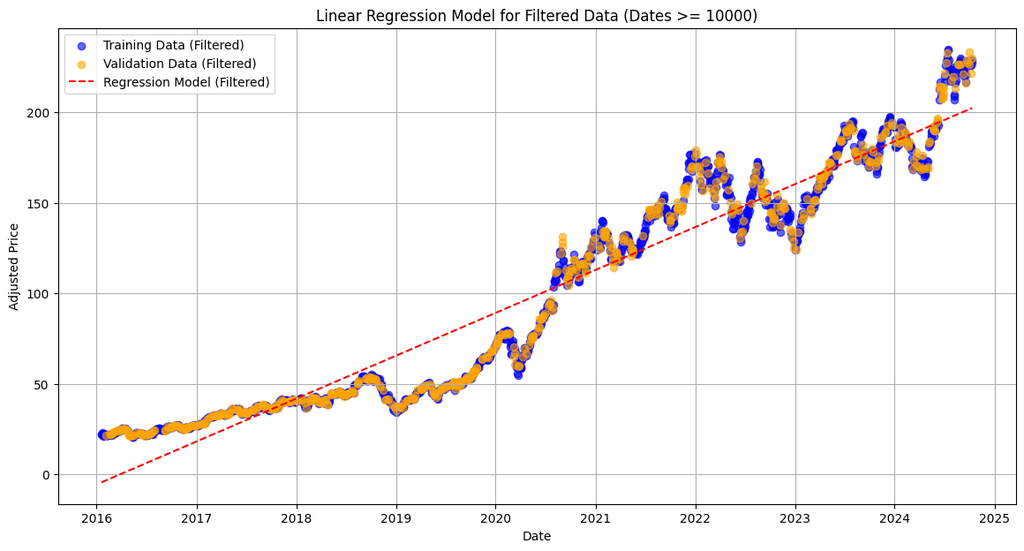

```python
from sklearn.model_selection import train_test_split
from sklearn.linear_model import LinearRegression
from sklearn.metrics import mean_squared_error, r2_score
import matplotlib.pyplot as plt

# Convert dates to numerical values (number of days since the start date)
apple_data['Days'] = (apple_data['Date'] - apple_data['Date'].min()).dt.days

# Filtered Dataset Regression Model (Days >= 10000/ from year 2016)
filtered_data = apple_data[apple_data['Days'] >= 10000].copy()

# Prepare the data for the filtered dataset regression
X_filtered = filtered_data['Days'].values.reshape(-1, 1)  # Independent variable: days since start date >= 10000
y_filtered = filtered_data['Adjusted Price'].values     # Dependent variable: adjusted prices

# Split the filtered dataset into training and validation sets (70% training, 30% validation)
X_train_filtered, X_val_filtered, y_train_filtered, y_val_filtered, train_idx_filtered, val_idx_filtered = train_test_split(
    X_filtered, y_filtered, filtered_data.index, test_size=0.3, random_state=42
)

# Create and fit the linear regression model for the filtered dataset
model_filtered = LinearRegression()
model_filtered.fit(X_train_filtered, y_train_filtered)

# Generate predictions for the training and validation sets (filtered dataset)
y_train_pred_filtered = model_filtered.predict(X_train_filtered)
y_val_pred_filtered = model_filtered.predict(X_val_filtered)

# Print evaluation metrics for the filtered dataset
print(f"Filtered Data Model Coefficient (Slope): {model_filtered.coef_[0]}")
print(f"Filtered Data Model Intercept: {model_filtered.intercept_}")
print(f"Filtered Data Training MSE: {mean_squared_error(y_train_filtered, y_train_pred_filtered):.2f}")
print(f"Filtered Data Training R²: {r2_score(y_train_filtered, y_train_pred_filtered):.2f}")
print(f"Filtered Data Validation MSE: {mean_squared_error(y_val_filtered, y_val_pred_filtered):.2f}")
print(f"Filtered Data Validation R²: {r2_score(y_val_filtered, y_val_pred_filtered):.2f}")

# Add predicted prices and convert "Days" back to actual dates for visualization
filtered_data['Predicted Price'] = model_filtered.predict(X_filtered)
filtered_data['Actual Date'] = filtered_data['Date']

# Visualize the filtered dataset regression with dates
plt.figure(figsize=(14, 7))
plt.scatter(filtered_data.loc[train_idx_filtered, 'Actual Date'], y_train_filtered, label='Training Data (Filtered)', color='blue', alpha=0.6)
plt.scatter(filtered_data.loc[val_idx_filtered, 'Actual Date'], y_val_filtered, label='Validation Data (Filtered)', color='orange', alpha=0.6)
plt.plot(filtered_data['Actual Date'], filtered_data['Predicted Price'], color='red', linestyle='--', label='Regression Model (Filtered)')
plt.title('Linear Regression Model for Filtered Data (Dates >= 10000)')
plt.xlabel('Date')
plt.ylabel('Adjusted Price')
plt.legend()
plt.grid(True)
plt.show()
```

In conclusion, for data that have already had an explicit trend, applying linear regression model can be an applicable choice. In our siuation, where Apple stock prices show a continuous trend of rasing from 2016, linear regression model can be predictable and explainable on how stock prices might change over time.

Citations:

Waskom, M., et al. (n.d.). Seaborn: Statistical Data Visualization. Retrieved November 13, 2024, from https://seaborn.pydata.org

QuantHub. (n.d.). How to Read a Correlation Heatmap. Retrieved December 5, 2024, from https://www.quanthub.com/how-to-read-a-correlation-heatmap/#:~:text=A%20correlation%20heatmap%20is%20a,closely%20related%20different%20variables%20are

ScienceDirect. (n.d.). Pearson Correlation. Retrieved December 5, 2024, from https://www.sciencedirect.com/topics/computer-science/pearson-correlation

Investopedia. (n.d.). Moving Average Convergence Divergence (MACD). Retrieved December 5, 2024, from https://www.investopedia.com/terms/m/macd.asp#:~:text=Key%20Takeaways,EMA%20of%20the%20MACD%20line